# Python Programming Workshop for Beginners

### Day 2: Functions & Data Analysis

### Sunday, Nov 19, 2017

### University of Waterloo

[figure not shown]

## Your questions

- how do we test if things are not equal?
- what is an index/indexing
- cheat sheet
- WTF for loops

## Memory refresher

- yesteday we learned about different data types (lists, dictionaries)
- **if-then** statements
- **for** loops
- and we wrote our own quiz!

## Today: functions give us superpowers!

- Learn what functions are, how are they used and write our own functions
- Use functions other people wrote
  - NumPy and Matplotlib
  - Simple data analysis: how does the amount of chocolate influence overall happiness?

Project: Analyze historical temperature values Canada

## Schedule

```
10:00 - 11:00: Work
11:00 - 11:05: Rest
11:10 - 12:15: Work

12:15 - 12:45: Lunch
12:45 - 14:45: Project
14:45 - 15:00: Python Demo (Deepak)
15:00 - 15:15: Wrap up
```

Slides available online at:

- http://uwpyb.github.io/materials/lectures/day_2.slides

Or a shorter link (it takes you to the same place):

- http://goo.gl/7fCHDg

## Functions

[figure not shown]

### Funtions we have used already

- `input(q)`: display message in **q** and return whatever user types
- `type(x)`: ask Python about the data type of x
- `len(x)`: ask Python to tell us the length of a variable x

## Functions

- a piece of code that we might want to run more than a few times
- our first function: Saying hello!

### Making a function

```python
def say_hello():
    print("Hello, world!")
```

### Using a function

```python
say_hello()
```

```
Hello, world!
```

### Function parts

[figure not shown]

### Exercise: Love letter

### Example: Converting kilograms to pounds

[figure not shown]

```python
def kg_to_lb(weight_kg):
    weight_lb = weight_kg * 2.2
    return weight_lb
```

```python
print(kg_to_lb(2))
```

```
4.4
```

### Exercise: pounds to kilograms

Write a function that converts pounds to kilograms. 1 lb = 0.454 kg, or 1 kg = 2.2 lb.

```
def lb_to_kg(weight_lb):
    weight_kg = weight_lb / 2.2
    return weight_kg
```

OR

```
def lb_to_kg(weight_lb):
    weight_kg = weight_lb * 0.454
    return weight_kg
```

How do we know if this function is correct?

```python
lb_to_kg(4.4)
```

```
2.0
```

```python
kg_to_lb(2)
```

```
4.4
```

### Counting letters in a word

```python
word = 'MORPHOGENESIS'
```

# Exercise

Put following lines in the right order so that the variable `length` at the end contains the number of letters in the word 'MORPHOGENESIS'

```
1. length = length + 1
```

```
2. length = 0
```

```
3. return length
```

```
4. for letter in word:
```

```
5. def count_letters(word):
```

```python
def count_letters(word):
    length = 0
    for letter in word:
        length = length + 1
    return length
```

# Exercise

What will the following line return?

```
count_letters('1')

a) Error
b) 1
c) '1'
```

```python
count_letters('1')
```

```
1
```

What will the following line return?

```
count_letterns('')

a) Error
b) 0
c) '0'
```

```python
count_letterns('')
```

```
------------------------------------------------------------
NameError                  Traceback (most recent call last)
<ipython-input-13-1b5f4c45ca2d> in <module>()
----> 1 count_letterns('')

NameError: name 'count_letterns' is not defined
```

What will the following line return?

```
count_letters(100)

a) Error
b) 3
c) 100
```

```python
count_letters(100)
```

```
------------------------------------------------------------
TypeError                  Traceback (most recent call last)
<ipython-input-14-e8e38327be8c> in <module>()
----> 1 count_letters(100)

<ipython-input-11-d9fc3c55f969> in count_letters(word)
      1 def count_letters(word):
      2     length = 0
----> 3     for letter in word:
      4         length = length + 1
      5     return length

TypeError: 'int' object is not iterable
```

## Multiple arguments

```python
def smaller(a, b):
    min_num = a
    if b < a:
        min_num = b
    return min_num
```

```python
small_number = smaller(5, 2)
print(small_number)
```

```
2
```

```python
print(smaller(-1, 10))
```

```
-1
```

## Exercise

Write a function that takes 2 strings and returns the longer one. When the two strings have the same length, return the first string.

```python
def longer_string(stringA, stringB):
    if len(stringA) >= len(stringB):
        return stringA
    else:
        return stringB
```

There are countless ways to write a program. Your program is correct as long as it produces the correct output

```python
longer_string("cilantro", "mint")
```

```
'cilantro'
```

```python
longer_string("cheddar", "mozzarella")
```

```
'mozzarella'
```

```python
longer_string("poutine", "cookies")
```

```
'poutine'
```

## Using functions other people wrote

[figure not shown]

## Using functions other people wrote

- ready-to-use functions are stored in packages called libraries
  - when we want to use a certain set of function we `import` that library
- usually you would install what you need on your computer (not everyone wants to make brownies!)

# Packages we will use today

- Numpy: for dealing with sequences of numbers
- Matplotlib: for plotting these sequences

# NumPy

- a collection of functions (and bunch of other things) for working with numbers in Python
- numbers in numpy are stored as sequences of numbers called *numpy arrays*

```python
import numpy as np
```

```python
numbers = np.arange(10)
print(numbers)
```

```
[0 1 2 3 4 5 6 7 8 9]
```

```python
np.zeros(5)
```

```
array([ 0.,  0.,  0.,  0.,  0.])
```

```python
np.ones(50)
```

```
array([ 1.,  1.,  1.,  1.,  1.,  1.,  1.,  1.,  1.,  1.,  1.,  1.,  1.,
        1.,  1.,  1.,  1.,  1.,  1.,  1.,  1.,  1.,  1.,  1.,  1.,  1.,
        1.,  1.,  1.,  1.,  1.,  1.,  1.,  1.,  1.,  1.,  1.,  1.,  1.,
        1.,  1.,  1.,  1.,  1.,  1.,  1.,  1.,  1.,  1.,  1.])
```

NumPy arrays can look very much like lists, but they are used for different things:

```python
array = np.arange(5)
li = [0, 1, 2, 3, 4]

print(array, ' is ', type(array))
print(li, 'is', type(li))
```

```
[0 1 2 3 4]  is  <class 'numpy.ndarray'>
[0, 1, 2, 3, 4] is <class 'list'>
```

Similar handling like lists:

```python
print('The first element of numbers is:', numbers[0])
print('The last element of numbers is:', numbers[-1])
print('The length of numbers is:', len(numbers))
```

```
The first element of numbers is: 0
The last element of numbers is: 9
The length of numbers is: 10
```

```python
mean = np.mean(numbers)
smallest_element = np.min(numbers)
print('Mean:', mean)
print('Smallest element:', smallest_element)
```

```
Mean: 4.5
Smallest element: 0
```

# Exercise

How would you get the largest element?

## Download the data for today!

1. Go here: https://github.com/uwpyb/materials/tree/master/lectures
2. You should find **chocolate.csv** file there. Click on it!
3. A short preview of the data in a table will appear in a new page. On that page, click on "Raw" and when a new white page opens with the data, right click "Save as..." (or "Save Page as..." on some computers) and select the workshop folder on your desktop to save the file.

## What are these `.csv` files?

### Let's peek into the files!

## Loading the data with NumPy

Using the **loadtxt** function from NumPy:

```python
chocolate = np.loadtxt('chocolate.csv', delimiter=',', skiprows=1)
```

```python
print(chocolate)
```

```
[[  0.   0.]
 [  1.   9.]
 [  2.  16.]
 [  3.  21.]
 [  4.  24.]
 [  5.  25.]
 [  6.  24.]
 [  7.  21.]
 [  8.  16.]
 [  9.   9.]
 [ 10.   0.]]
```

```python
print(type(chocolate))
```

```
<class 'numpy.ndarray'>
```

```python
print(chocolate.shape)
```

```
(11, 2)
```

```python
print("The first row:", chocolate[0, :])
```

```
The first row: [ 0.  0.]
```

```python
print("The first five rows:")
print(chocolate[0:5, :])
```

```
The first five rows:
[[  0.   0.]
 [  1.   9.]
 [  2.  16.]
 [  3.  21.]
 [  4.  24.]]
```

```python
print("The first column:", chocolate[:, 0])
```

```
The first column: [  0.   1.   2.   3.   4.   5.   6.   7.   8.   9.  10.]
```

```python
number_of_chocolates = chocolate[:, 0]
```

```python
happiness = chocolate[:, 1]
print("Happiness is:", happiness)
```

```
Happiness is: [  0.   9.  16.  21.  24.  25.  24.  21.  16.   9.   0.]
```

## Exercise

1. Use NumPy to find the maximal happiness value with chocolate bars
2. Find the average amount of chocolate bars in this data set

### More stuff with arrays in the project!

Next: Plotting!

# Matplotlib

- our friend for visualizing data in Python!

```python
import matplotlib.pyplot as plt
```

```python
# you don't have to copy this line
%matplotlib inline
```

# Plotting squares

```python
line = np.arange(5)
print('Line:', line)
print('Squared line:', line**2)
```

```
Line: [0 1 2 3 4]
Squared line: [ 0  1  4  9 16]
```

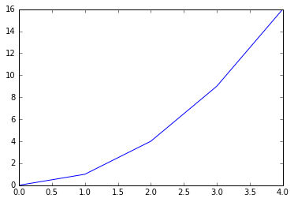

```python
plt.figure()
plt.plot(line, line**2)
plt.show()
```

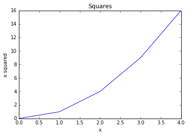

```python
plt.figure()
plt.title('Squares')
plt.plot(line, line**2)
plt.xlabel('x')
plt.ylabel('x squared')
plt.show()
```

## Plotting: chocolate over happiness

```python
chocolate = np.loadtxt('chocolate.csv', delimiter=',', skiprows=1)
number_of_chocolates = chocolate[:, 0]
happiness = chocolate[:, 1]
```

## Plotting: chocolate over happiness

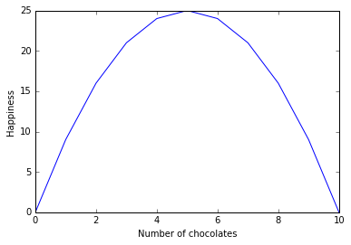

```python
plt.figure()
plt.plot(number_of_chocolates, happiness)
plt.xlabel('Number of chocolates')
plt.ylabel('Happiness')

plt.savefig('chocolate.png')
```

## Another kind of plot (just for fun!)

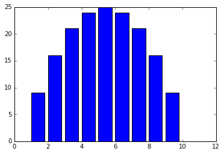

```python
plt.figure()
plt.bar(number_of_chocolates, happiness)
plt.show()
```

## Exercise

1. Add labels to the plot
2. Find a way to change the color of the bars (use help, either Google or "?" in IPython)
3. Make the bars thinner
4. Harder: Change the background color

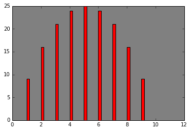

```python
plt.figure()
plt.subplot('111', axisbg='gray')
plt.bar(number_of_chocolates, happiness, color='r', width=0.2)
plt.show()
```

## The End!

The project: https://github.com/uwpyb/materials/blob/master/projects/Day2_DataAnalysis.ipynb

Or a shorter link: https://goo.gl/7aRpZZ

We'll be back with the short wrap-up discussion at 14:45!

## What's next?

- more information about available resources
- take advantage of CS courses at the Uni: CS 116 is also using Python

## Thanks!

Lunches and coffee breaks provided by:

- Women in Computer Science @ UW:
- Google for Education Program:
- And many nice people all over the world who write programs for free, so other people can use them, learn and improve!

Help us by filling out the short survey! (coming soon)